# SeqAn Usage Statistics

This report shows how SeqAn applications are used. It is created automatically from the log of the SeqAn telemetry server and from public download, GitHub and Google Scholar statistics.

Telemetry requires explicit consent.  
Non-interactive sessions are opt-out by default.

ZIP

Sections with tabs show all data and, in separate tabs, each year since 2023; the tab of a year only uses the calls of this year. The plots over time have a *TSV per year* with their values summed per period: each full year since 2023, the fourth quarter of the previous year to the third quarter of the current year, and the current year.

## Timeframe

The first and the last day with a call in the log, and the day on which the report was created. If the log ends before the end of a month, the values of this month cover only part of it.

| What | Date |
| --- | --- |
| From | 2020-02-23 |
| To | 2025-01-25 |
| Today | 2026-11-11 |

The timeframe spans 257 weeks and 0 days.  
This is equivalent to 1,799 days or 257.00 weeks.

## The Data

A telemetry request is a line of the server log that requests `/check/<who>_<os>_<cpu>_<app>_<version>` from an IPv4 address, for example `/check/SeqAn3_Linux_64_needle_1.0.3`. The log is processed as follows:

- **Excluded:** Requests that do not match this format, e.g. without a version of the form x.y.z, and requests of test programs (`test_version_check`, `program_full_options`, `empty_options`, `default`, `myApp`, `test_parser`).
- **Call:** An application counts at most once per day for each combination of IP address, version, operating system, CPU mode and `who`. Such a combination is a *call*; all numbers of calls in this report count these. Days are taken from the time stamps of the server.
- **Cluster calls:** Within a day, the calls are sorted by IP address, application and version, compared as text byte by byte (e.g. 10.1.0.1 before 9.1.0.1). A call is a *cluster call* if the call directly before it is for the same application and version from an IP address in the same /16 network (same first two numbers), including the same address. Cluster calls are left out of all statistics; only the top 10 applications show them separately.
- **User:** A *user* is an IP address. Several people can share an address, for example behind the gateway of an institute, and one person can use several addresses, so the number of IP addresses only approximates the number of people.
- **Location:** Country, region, city and coordinates of an IP address are taken from the IP2Location LITE DB5 database and are approximate. Addresses that are not in the database have the country `-` and the coordinates 0, 0.
- **Operating system:** `unknown` counts as Linux.
- **Tool tag:** Each application has the tag of the project’s tool tag list, e.g. de.NBI; applications that are not in the list are tagged `extern`.

The resulting table has the following columns:

| ID | Name | Description |
| --- | --- | --- |
| 1 | app | Application name |
| 2 | ip | IP address |
| 3 | calls | Always 1: each row is one call |
| 4 | date | Date of the call |
| 5 | version | Application version |
| 6 | cpu | CPU-Mode (32/64-bit) |
| 7 | os | The operating system |
| 8 | who | How the call was sent (e.g., library, KNIME) |
| 9 | clustered | 1 for a cluster call |
| 10 | country_code | Country code¹ |
| 11 | country | Country¹ |
| 12 | region | Region¹ |
| 13 | city | City¹ |
| 14 | longitude | Longitude¹ |
| 15 | latitude | Latitude¹ |
| 16 | DevelopedBy | Tool tag |

¹ Derived from IP

## Citations

Citations per year of a set of important [selected publications](https://scholar.google.de/citations?hl=de&user=JWLBQHwAAAAJ) about or using SeqAn, as reported by Google Scholar at the time shown in the plot:

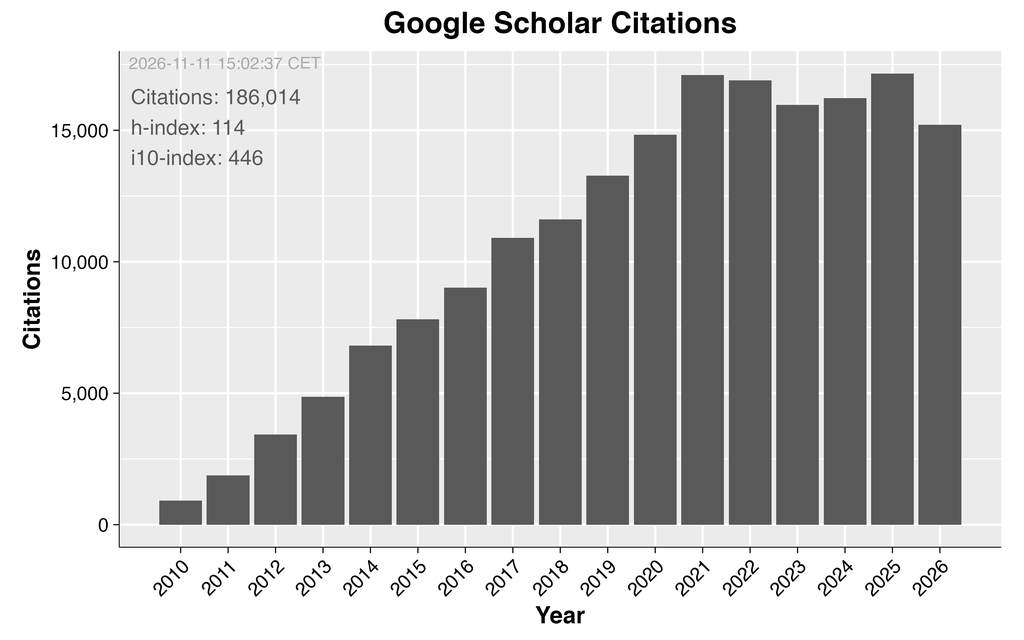

PDF PNG TSV

## Downloads

Downloads of the SeqAn libraries and applications, fetched on 2026-11-11. Which GitHub repositories and conda and PyPI packages count as library or application is configured per project; other packages are not counted.

- **GitHub:** Downloads of release assets, without `.sha256` files and release candidates. GitHub only reports the total of each asset since its release, so the downloads of a release are distributed evenly over the days until the next release of the same repository, or up to the fetch date for the latest release of a repository. As the totals keep growing and the latest releases are distributed over more days, the values of past periods can change when the statistics are fetched again.
- **Conda:** Monthly downloads of the packages from all channels (e.g. bioconda, conda-forge) in the public anaconda-package-data dataset.
- **PyPI:** Monthly downloads of the packages from the public PyPI dataset on ClickHouse.

The periods are each full year since 2023, the fourth quarter of the previous year to the third quarter of the current year, and the current year.

### Libraries

| Start | End | GitHub Downloads | Conda Downloads | PyPI Downloads | Total Downloads |
| --- | --- | --- | --- | --- | --- |
| 2023 Q1 | 2023 Q4 | 7768.0 | 4575.0 | 0.0 | 12343.0 |
| 2024 Q1 | 2024 Q4 | 9461.0 | 4044.0 | 0.0 | 13505.0 |
| 2025 Q1 | 2025 Q4 | 3910.0 | 19593.0 | 0.0 | 23503.0 |
| 2025 Q4 | 2026 Q3 | 8670.0 | 16309.0 | 0.0 | 24979.0 |
| 2026 Q1 | 2026 Q4 | 8573.0 | 11258.0 | 0.0 | 19831.0 |

TSV

### Apps

| Start | End | GitHub Downloads | Conda Downloads | PyPI Downloads | Total Downloads |
| --- | --- | --- | --- | --- | --- |
| 2023 Q1 | 2023 Q4 | 855.0 | 23085.0 | 0.0 | 23940.0 |
| 2024 Q1 | 2024 Q4 | 1159.0 | 19513.0 | 0.0 | 20672.0 |
| 2025 Q1 | 2025 Q4 | 928.0 | 161128.0 | 0.0 | 162056.0 |
| 2025 Q4 | 2026 Q3 | 928.0 | 97116.0 | 0.0 | 98044.0 |
| 2026 Q1 | 2026 Q4 | 801.0 | 58988.0 | 0.0 | 59789.0 |

TSV

## GitHub Issues and PR

Issues and pull requests of all repositories of the SeqAn GitHub organization, fetched on 2026-11-11. Each is counted in the period in which it was opened and in the period in which it was closed (Europe/Berlin time); merged pull requests count as closed. The periods are the same as for the downloads.

| Start | End | Issues Opened | Issues Closed | PRs Opened | PRs Closed |
| --- | --- | --- | --- | --- | --- |
| 2023 Q1 | 2023 Q4 | 73.0 | 78.0 | 740.0 | 736.0 |
| 2024 Q1 | 2024 Q4 | 56.0 | 41.0 | 477.0 | 458.0 |
| 2025 Q1 | 2025 Q4 | 19.0 | 18.0 | 636.0 | 634.0 |
| 2025 Q4 | 2026 Q3 | 12.0 | 9.0 | 499.0 | 504.0 |
| 2026 Q1 | 2026 Q4 | 12.0 | 11.0 | 445.0 | 447.0 |

TSV

## General Usage

Cumulative number of calls of all applications over time, by tool tag. TSV per year: the calls in each period, by tool tag.

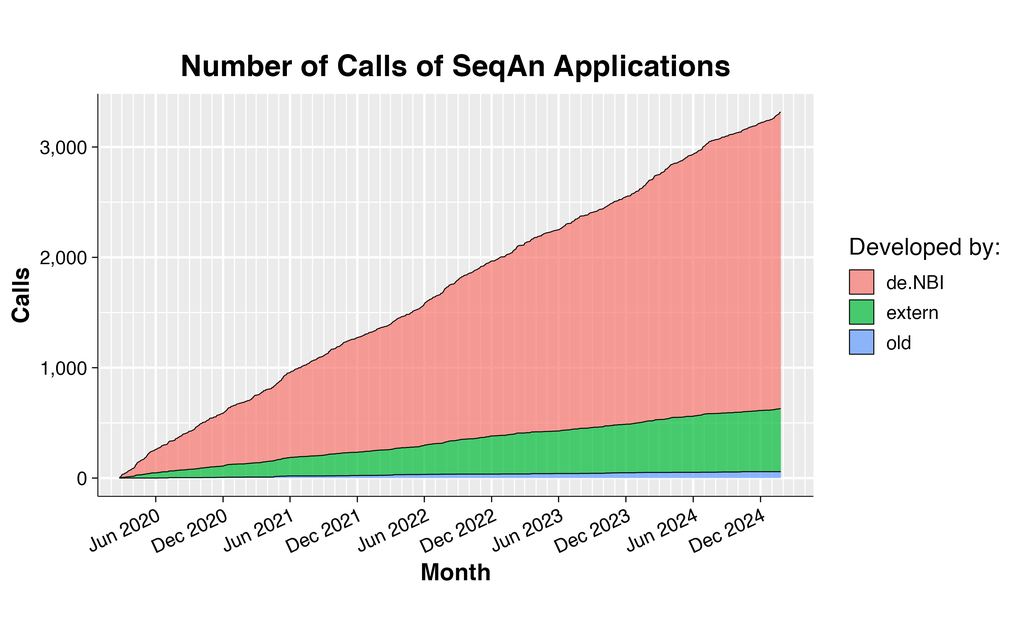

PDF PNG TSV TSV per year

## Worldmap

SeqAn Worldmap: Program calls with telemetry enabled (blue circles = call frequency)

Each circle is a location from the geolocation of the IP addresses; its radius grows logarithmically with the number of calls from there. Click a circle to see the calls per application. All maps start at, and reset to, the area of all data, and switching tabs keeps the current view.

### All data

[interactive chart not shown]

### 2023

[interactive chart not shown]

### 2024

[interactive chart not shown]

### 2025

[interactive chart not shown]

## Top 10 Applications

The ten applications with the most individual calls (By Calls) or individual users (By Users) in the timeframe of the tab.

- **Individual calls and users:** The calls that are not cluster calls, and their IP addresses.
- **Cluster calls:** The calls of the application that are left out as cluster calls (see The Data).
- **Cluster users:** IP addresses whose calls of the application are all cluster calls. Individual and cluster users together are all IP addresses with a call of the application.

### All data

#### By Calls

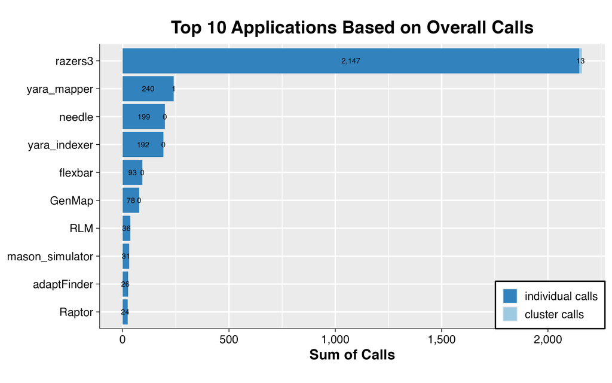

PDF PNG TSV

#### By Users

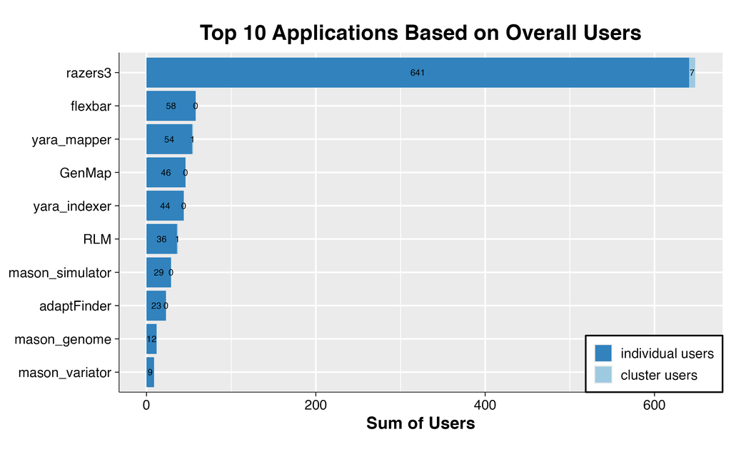

PDF PNG TSV

### 2023

#### By Calls

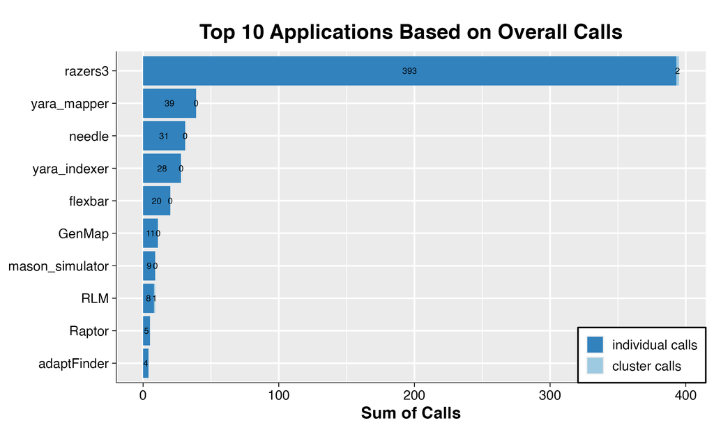

PDF PNG TSV

#### By Users

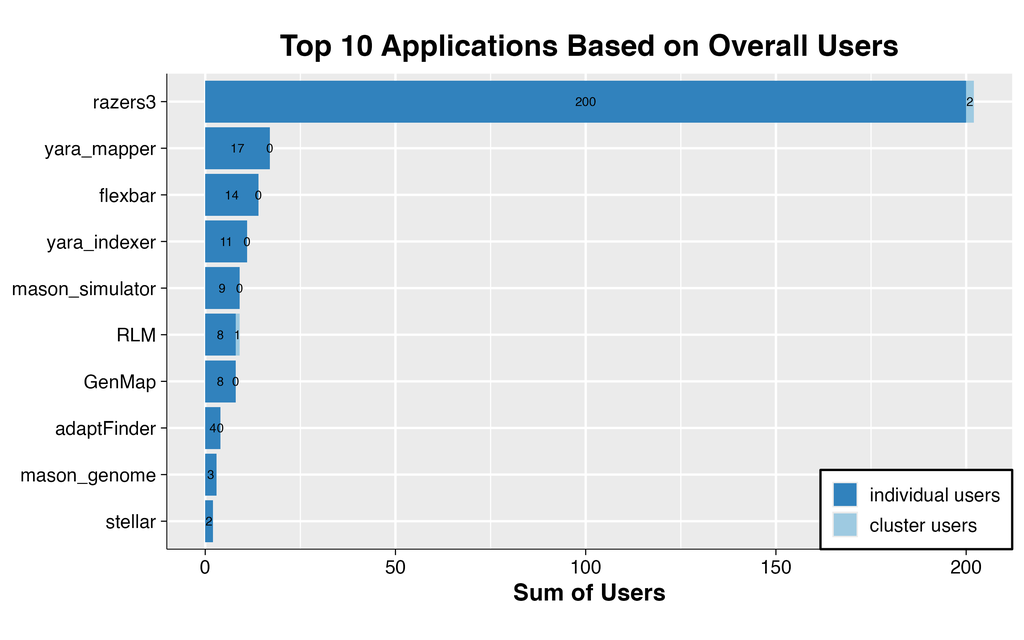

PDF PNG TSV

### 2024

#### By Calls

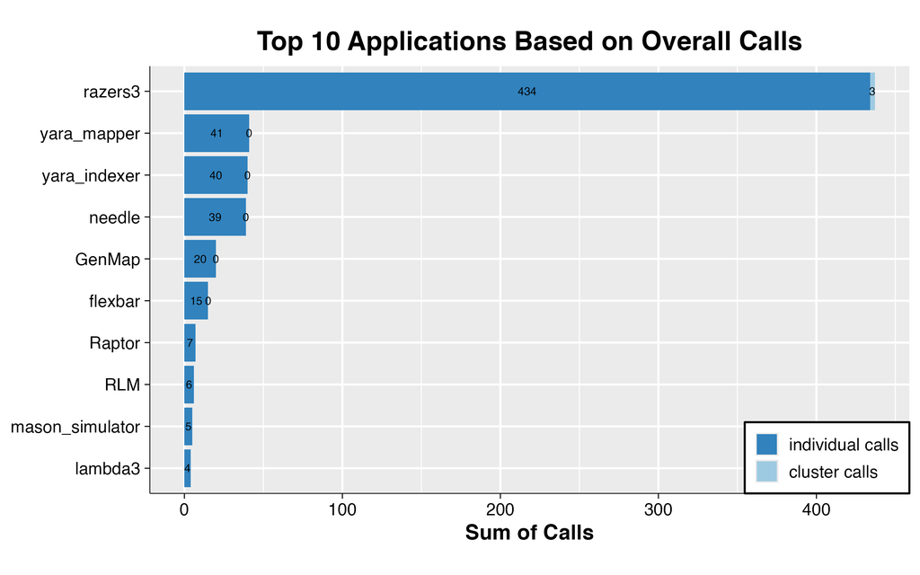

PDF PNG TSV

#### By Users

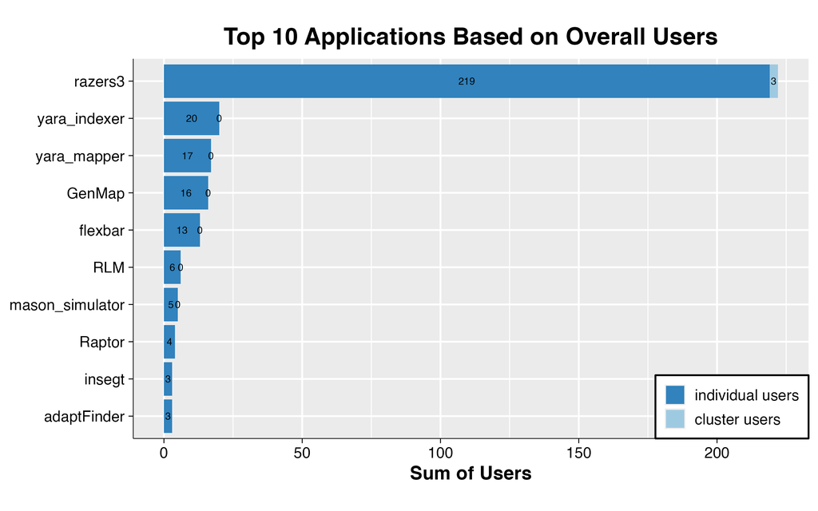

PDF PNG TSV

### 2025

#### By Calls

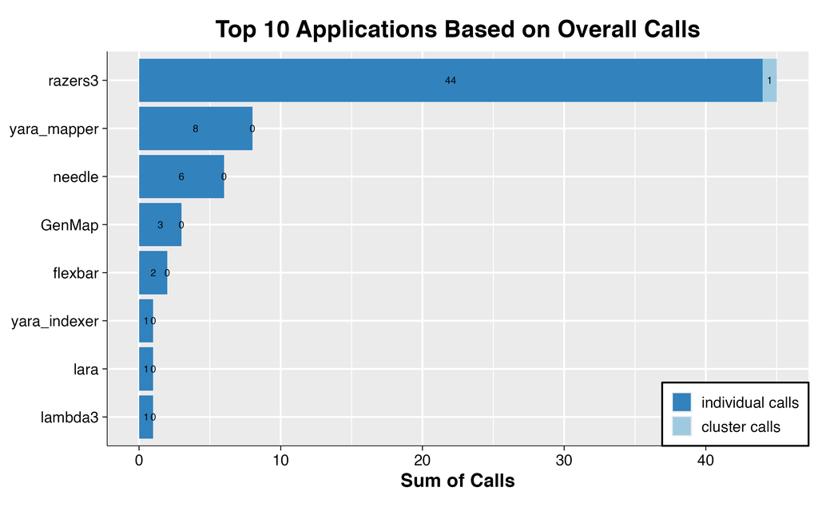

PDF PNG TSV

#### By Users

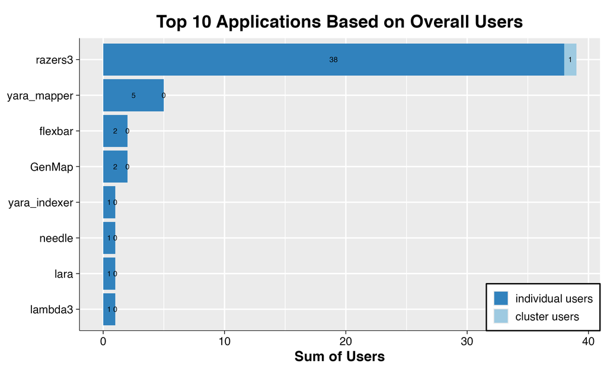

PDF PNG TSV

## Operating System

Share of the calls (By Calls) and of the IP addresses (By Users) per operating system. An IP address with calls from several operating systems counts for each of them.

### By Calls

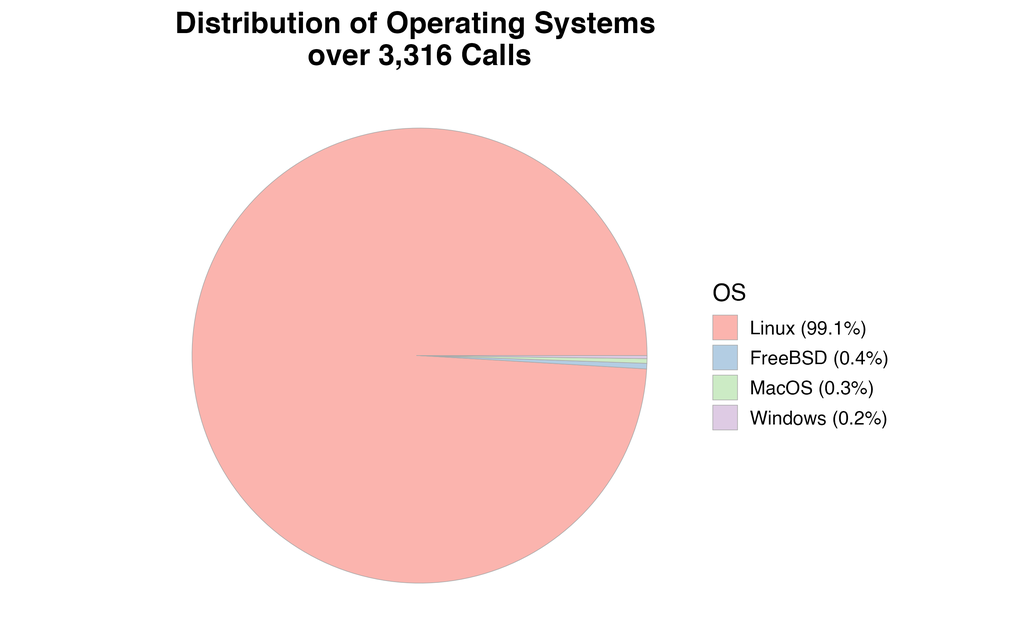

PDF PNG TSV

### By Users

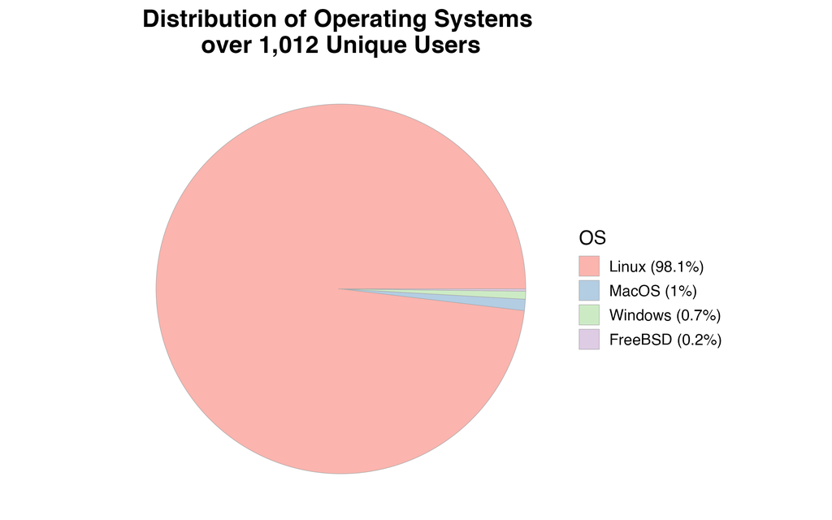

PDF PNG TSV

## New Unique User Statistic

A *new unique user* is an IP address in the month of its first call in the log. Each IP address counts once in the whole log (since 2020-02-23); in the first months of the log, this includes addresses that were already in use before. The red line is the cumulative sum, i.e. the number of distinct IP addresses up to the month. TSV per year: the monthly values summed per period, i.e. the IP addresses whose first call in the log is in the period.

### Bar

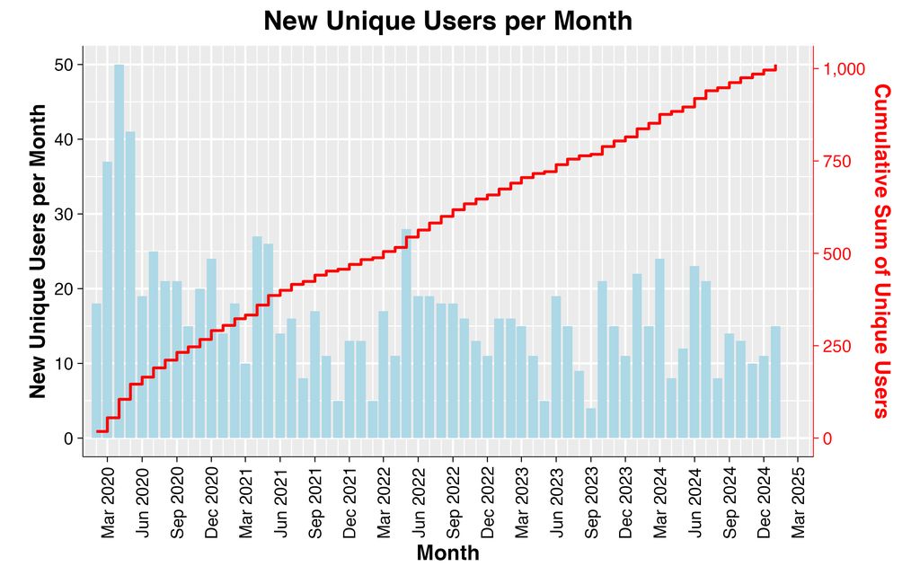

PDF PNG TSV TSV per year

### Line

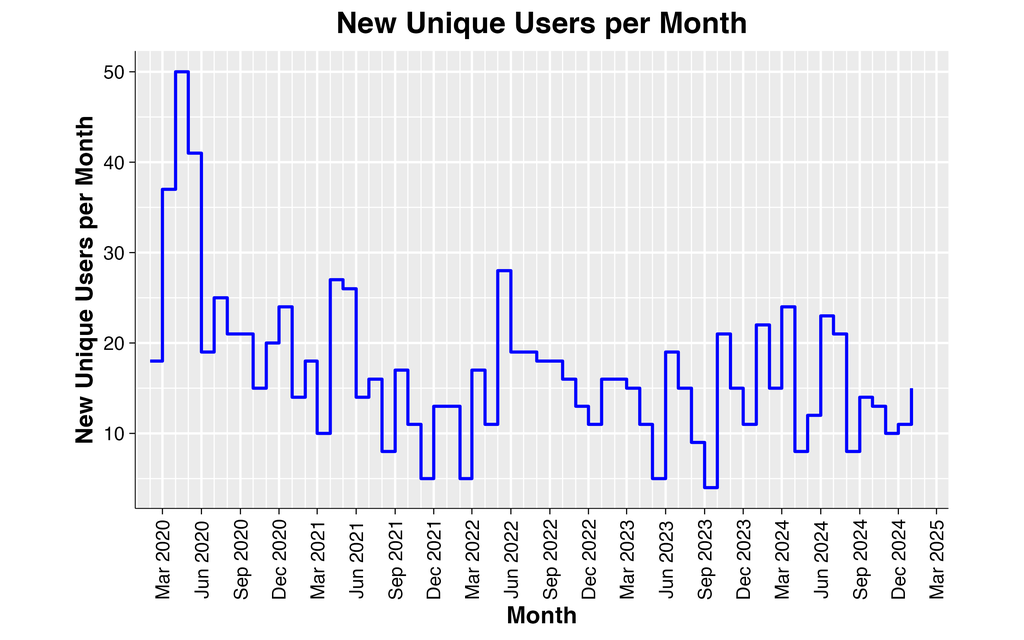

PDF PNG TSV TSV per year

## Unique User Statistic

The number of distinct IP addresses with a call in the month. An IP address counts once per month, in each month in which it has a call. The red line is the cumulative sum of the monthly values; as an IP address counts again in each month, this is not the number of distinct IP addresses. TSV per year: the monthly values summed per period (Sum_of_Monthly_Unique_Users), with the same caveat.

### Bar

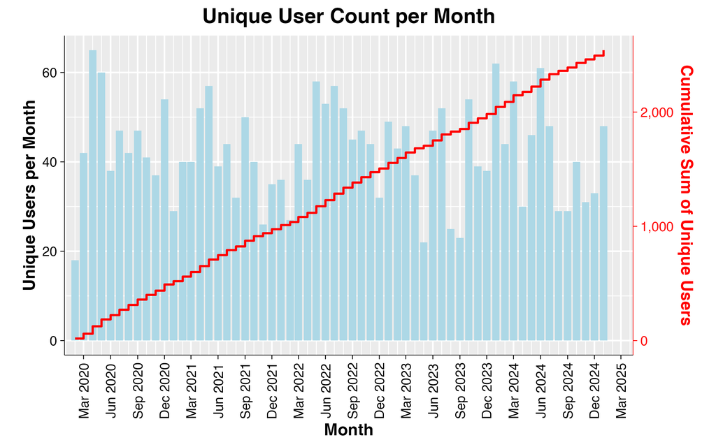

PDF PNG TSV TSV per year

### Line

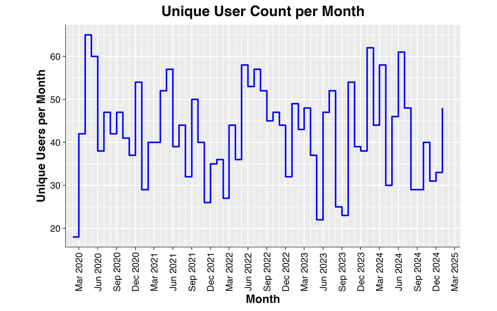

PDF PNG TSV TSV per year

## Total Calls Statistic

The number of calls per month (see The Data); the red line is the cumulative sum. TSV per year: the monthly values summed per period.

### Bar

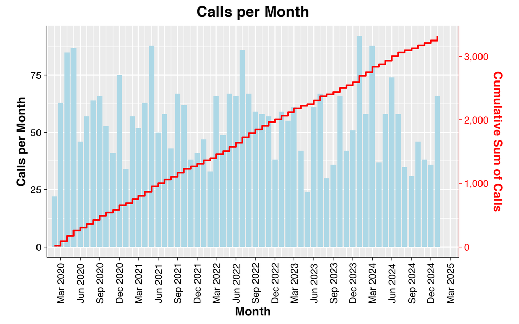

PDF PNG TSV TSV per year

### Line

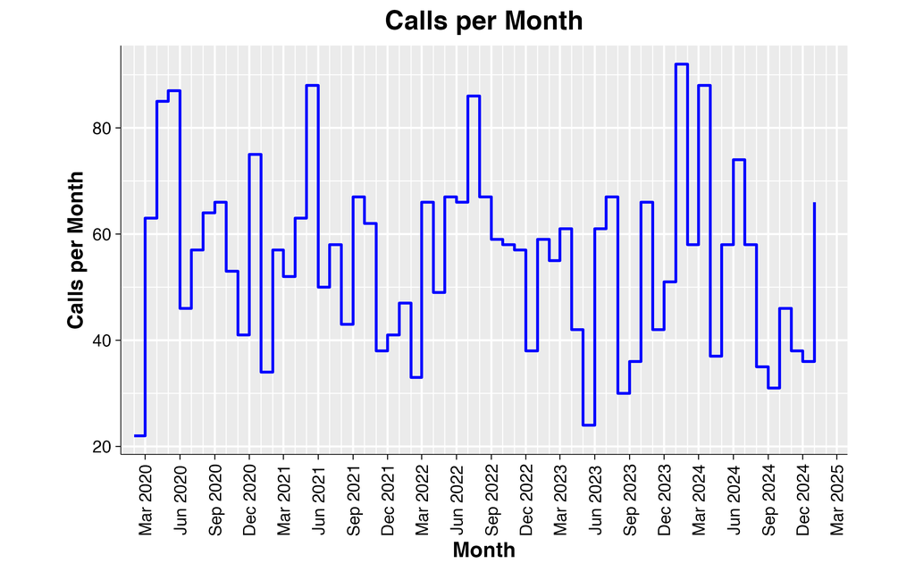

PDF PNG TSV TSV per year

## Distribution of Countries and Cities

For each application, the number of countries and cities with a call, and the country and the city with the most calls. Cities are distinguished by name, region and country, and shown as *City (Region, Country)*.

### All data

| Application | Countries | Cities | Country with most calls | Calls from Country | City with most calls | Calls from City |
| --- | --- | --- | --- | --- | --- | --- |
| razers3 | 51.0 | 288.0 | United States of America | 847.0 | Ashburn (Virginia, United States of America) | 174.0 |
| flexbar | 24.0 | 44.0 | United States of America | 44.0 | Columbus (Ohio, United States of America) | 25.0 |
| GenMap | 19.0 | 38.0 | Japan | 24.0 | Tokyo (Tokyo, Japan) | 24.0 |
| yara_indexer | 18.0 | 35.0 | Japan | 66.0 | Tokyo (Tokyo, Japan) | 64.0 |
| yara_mapper | 14.0 | 41.0 | United States of America | 85.0 | Tokyo (Tokyo, Japan) | 65.0 |
| RLM | 13.0 | 23.0 | United States of America | 15.0 | Tokyo (Tokyo, Japan) | 7.0 |
| adaptFinder | 11.0 | 22.0 | United States of America | 9.0 | Tempe (Arizona, United States of America) | 3.0 |
| mason_simulator | 10.0 | 26.0 | United States of America | 19.0 | Shanghai (Shanghai, China) | 3.0 |
| mason_genome | 7.0 | 11.0 | United States of America | 5.0 | Beijing (Beijing, China) | 2.0 |
| alf | 4.0 | 5.0 | United States of America | 5.0 | North Bergen (New Jersey, United States of America) | 4.0 |
| gustaf_mate_joining | 4.0 | 5.0 | United States of America | 4.0 | North Bergen (New Jersey, United States of America) | 3.0 |
| mason_variator | 4.0 | 9.0 | United States of America | 6.0 | Amsterdam (Noord-Holland, Netherlands (Kingdom of the)) | 1.0 |
| seqan_tcoffee | 4.0 | 6.0 | United States of America | 3.0 | Fontana Liri (Lazio, Italy) | 1.0 |
| Indexer | 3.0 | 3.0 | United States of America | 2.0 | North Bergen (New Jersey, United States of America) | 2.0 |
| Penguin_Parade | 3.0 | 3.0 | United States of America | 3.0 | North Bergen (New Jersey, United States of America) | 3.0 |
| Raptor | 3.0 | 6.0 | United States of America | 21.0 | North Bergen (New Jersey, United States of America) | 18.0 |
| Test | 3.0 | 3.0 | Switzerland | 2.0 | Zurich (Zurich, Switzerland) | 2.0 |
| compute_gain | 3.0 | 3.0 | Finland | 1.0 | Amsterdam (Noord-Holland, Netherlands (Kingdom of the)) | 1.0 |
| dfi | 3.0 | 3.0 | United States of America | 2.0 | North Bergen (New Jersey, United States of America) | 2.0 |
| fiona_illumina | 3.0 | 3.0 | Denmark | 1.0 | Amsterdam (Noord-Holland, Netherlands (Kingdom of the)) | 1.0 |
| fx_bam_coverage | 3.0 | 3.0 | Brazil | 1.0 | Franca (Sao Paulo, Brazil) | 1.0 |
| lambda | 3.0 | 6.0 | United States of America | 5.0 | Honolulu (Hawaii, United States of America) | 2.0 |
| lambda2 | 3.0 | 3.0 | Colombia | 1.0 | Bucaramanga (Santander, Colombia) | 1.0 |
| lambda3 | 3.0 | 3.0 | Switzerland | 16.0 | Zurich (Zurich, Switzerland) | 16.0 |
| lambda_indexer | 3.0 | 5.0 | United States of America | 5.0 | Honolulu (Hawaii, United States of America) | 3.0 |
| needle | 3.0 | 4.0 | Spain | 194.0 | Vigo (Galicia, Spain) | 194.0 |
| ovgraphbuild | 3.0 | 4.0 | United States of America | 6.0 | Detroit (Michigan, United States of America) | 5.0 |
| rabema_prepare_sam | 3.0 | 3.0 | Italy | 1.0 | Amsterdam (Noord-Holland, Netherlands (Kingdom of the)) | 1.0 |
| roi_feature_projection | 3.0 | 4.0 | Brazil | 2.0 | Al Mazzunah (Sidi Bouzid, Tunisia) | 1.0 |
| samcat | 3.0 | 3.0 | Denmark | 1.0 | Frederiksberg (Hovedstaden, Denmark) | 1.0 |
| stellar | 3.0 | 6.0 | United States of America | 7.0 | North Bergen (New Jersey, United States of America) | 4.0 |
| fiona | 2.0 | 6.0 | United States of America | 6.0 | Charlotte (North Carolina, United States of America) | 2.0 |
| gustaf | 2.0 | 2.0 | Finland | 1.0 | Espoo (Uusimaa, Finland) | 1.0 |
| insegt | 2.0 | 5.0 | United States of America | 5.0 | North Bergen (New Jersey, United States of America) | 2.0 |
| lara | 2.0 | 2.0 | China | 2.0 | Wuhan (Hubei, China) | 2.0 |
| my_program | 2.0 | 2.0 | Switzerland | 3.0 | North Bergen (New Jersey, United States of America) | 3.0 |
| mygit | 2.0 | 2.0 | Netherlands (Kingdom of the) | 2.0 | Amsterdam (Noord-Holland, Netherlands (Kingdom of the)) | 2.0 |
| pair_align | 2.0 | 2.0 | Indonesia | 1.0 | Mulia (Gorontalo, Indonesia) | 1.0 |
| rabema_evaluate | 2.0 | 3.0 | United States of America | 2.0 | Chita (Zabaykal’skiy kray, Russian Federation) | 1.0 |
| sak | 2.0 | 2.0 | China | 1.0 | Beijing (Beijing, China) | 1.0 |
| sam2matrix | 2.0 | 5.0 | United States of America | 3.0 | Columbus (Ohio, United States of America) | 1.0 |
| slimm | 2.0 | 2.0 | Netherlands (Kingdom of the) | 2.0 | Nijmegen (Gelderland, Netherlands (Kingdom of the)) | 2.0 |
| tree_recon | 2.0 | 3.0 | United States of America | 4.0 | North Bergen (New Jersey, United States of America) | 3.0 |
| AnnotateBam | 1.0 | 1.0 | China | 2.0 | Hangzhou (Zhejiang, China) | 2.0 |
| Contamination | 1.0 | 1.0 | China | 2.0 | Hangzhou (Zhejiang, China) | 2.0 |
| Demultiplexer | 1.0 | 1.0 | Malaysia | 1.0 | Kampung Kadok (Kelantan, Malaysia) | 1.0 |
| HmnTrimmer | 1.0 | 1.0 | Hong Kong | 1.0 | Hong Kong (Hong Kong, Hong Kong) | 1.0 |
| Mapper | 1.0 | 1.0 | Switzerland | 1.0 | Zurich (Zurich, Switzerland) | 1.0 |
| MergeBam | 1.0 | 1.0 | China | 2.0 | Hangzhou (Zhejiang, China) | 2.0 |
| MinionReadAnalyzer | 1.0 | 1.0 | China | 2.0 | Shanghai (Shanghai, China) | 2.0 |
| Search | 1.0 | 1.0 | Singapore | 1.0 | Singapore (Singapore, Singapore) | 1.0 |
| bam2roi | 1.0 | 1.0 | United States of America | 1.0 | North Bergen (New Jersey, United States of America) | 1.0 |
| bisar | 1.0 | 1.0 | United States of America | 1.0 | San Francisco (California, United States of America) | 1.0 |
| casbar | 1.0 | 2.0 | United States of America | 2.0 | Madison (Wisconsin, United States of America) | 1.0 |
| corrprofile | 1.0 | 1.0 | United States of America | 1.0 | Columbus (Ohio, United States of America) | 1.0 |
| count | 1.0 | 1.0 | New Zealand | 1.0 | Christchurch (Canterbury, New Zealand) | 1.0 |
| customgenomegenerator | 1.0 | 1.0 | Switzerland | 2.0 | Zurich (Zurich, Switzerland) | 2.0 |
| four2three | 1.0 | 1.0 | United States of America | 1.0 | North Bergen (New Jersey, United States of America) | 1.0 |
| fx_fastq_stats | 1.0 | 2.0 | United States of America | 2.0 | Ashburn (Virginia, United States of America) | 1.0 |
| ibf_bitscore | 1.0 | 1.0 | Argentina | 1.0 | Salta (Salta, Argentina) | 1.0 |
| join | 1.0 | 1.0 | United States of America | 1.0 | North Bergen (New Jersey, United States of America) | 1.0 |
| kgl_phylo | 1.0 | 1.0 | United States of America | 1.0 | Little Rock (Arkansas, United States of America) | 1.0 |
| mason_frag_sequencing | 1.0 | 1.0 | United States of America | 1.0 | North Bergen (New Jersey, United States of America) | 1.0 |
| mason_materializer | 1.0 | 2.0 | United States of America | 2.0 | Bellevue (Washington, United States of America) | 1.0 |
| mason_methylation | 1.0 | 1.0 | Korea (the Republic of) | 1.0 | Seongnam (Gyeonggi-do, Korea (the Republic of)) | 1.0 |
| mason_splicing | 1.0 | 1.0 | United States of America | 1.0 | North Bergen (New Jersey, United States of America) | 1.0 |
| mhc | 1.0 | 1.0 | Taiwan (Province of China) | 1.0 | Taipei (Taipei, Taiwan (Province of China)) | 1.0 |
| micro_razers | 1.0 | 1.0 | United States of America | 1.0 | North Bergen (New Jersey, United States of America) | 1.0 |
| minions | 1.0 | 1.0 | Switzerland | 16.0 | Zurich (Zurich, Switzerland) | 16.0 |
| pizzly | 1.0 | 1.0 | United States of America | 1.0 | Honolulu (Hawaii, United States of America) | 1.0 |
| rabema_build_gold_standard | 1.0 | 2.0 | United States of America | 2.0 | Cupertino (California, United States of America) | 1.0 |
| razers | 1.0 | 1.0 | United States of America | 1.0 | North Bergen (New Jersey, United States of America) | 1.0 |
| select | 1.0 | 1.0 | New Zealand | 1.0 | Christchurch (Canterbury, New Zealand) | 1.0 |
| singleCellPipe | 1.0 | 1.0 | United States of America | 1.0 | Tampa (Florida, United States of America) | 1.0 |
| slimm_build | 1.0 | 1.0 | United States of America | 1.0 | North Bergen (New Jersey, United States of America) | 1.0 |
| snp_store | 1.0 | 3.0 | United States of America | 4.0 | North Bergen (New Jersey, United States of America) | 2.0 |
| st_index_search | 1.0 | 2.0 | United States of America | 3.0 | North Bergen (New Jersey, United States of America) | 2.0 |
| umis_per_barcode | 1.0 | 1.0 | New Zealand | 1.0 | Christchurch (Canterbury, New Zealand) | 1.0 |
| valik | 1.0 | 1.0 | United States of America | 2.0 | Atlanta (Georgia, United States of America) | 2.0 |

TSV

### 2023

| Application | Countries | Cities | Country with most calls | Calls from Country | City with most calls | Calls from City |
| --- | --- | --- | --- | --- | --- | --- |
| razers3 | 36.0 | 117.0 | United States of America | 164.0 | Ashburn (Virginia, United States of America) | 33.0 |
| yara_mapper | 9.0 | 15.0 | United States of America | 14.0 | Tokyo (Tokyo, Japan) | 10.0 |
| flexbar | 8.0 | 13.0 | United States of America | 13.0 | Columbus (Ohio, United States of America) | 6.0 |
| GenMap | 7.0 | 8.0 | Japan | 3.0 | Tokyo (Tokyo, Japan) | 3.0 |
| RLM | 7.0 | 8.0 | United States of America | 2.0 | Bern (Bern, Switzerland) | 1.0 |
| yara_indexer | 6.0 | 10.0 | Japan | 12.0 | Tokyo (Tokyo, Japan) | 11.0 |
| mason_simulator | 5.0 | 9.0 | United States of America | 5.0 | Detroit (Michigan, United States of America) | 1.0 |
| adaptFinder | 4.0 | 4.0 | China | 1.0 | Fontana Liri (Lazio, Italy) | 1.0 |
| mason_genome | 3.0 | 3.0 | China | 1.0 | Beijing (Beijing, China) | 1.0 |
| Indexer | 2.0 | 2.0 | Switzerland | 1.0 | North Bergen (New Jersey, United States of America) | 1.0 |
| Penguin_Parade | 2.0 | 2.0 | Switzerland | 1.0 | North Bergen (New Jersey, United States of America) | 1.0 |
| Raptor | 2.0 | 2.0 | United States of America | 4.0 | North Bergen (New Jersey, United States of America) | 4.0 |
| lambda_indexer | 2.0 | 2.0 | Chile | 2.0 | Santiago (Region Metropolitana de Santiago, Chile) | 2.0 |
| lara | 2.0 | 2.0 | China | 1.0 | Columbus (Ohio, United States of America) | 1.0 |
| needle | 2.0 | 2.0 | Spain | 30.0 | Vigo (Galicia, Spain) | 30.0 |
| HmnTrimmer | 1.0 | 1.0 | Hong Kong | 1.0 | Hong Kong (Hong Kong, Hong Kong) | 1.0 |
| alf | 1.0 | 1.0 | United States of America | 3.0 | North Bergen (New Jersey, United States of America) | 3.0 |
| casbar | 1.0 | 2.0 | United States of America | 2.0 | Madison (Wisconsin, United States of America) | 1.0 |
| compute_gain | 1.0 | 1.0 | United Kingdom of Great Britain and Northern Ireland | 1.0 | Newport (Wales, United Kingdom of Great Britain and Northern Ireland) | 1.0 |
| customgenomegenerator | 1.0 | 1.0 | Switzerland | 1.0 | Zurich (Zurich, Switzerland) | 1.0 |
| fiona | 1.0 | 1.0 | United States of America | 1.0 | Carlsbad (California, United States of America) | 1.0 |
| fx_bam_coverage | 1.0 | 1.0 | Italy | 1.0 | Milan (Lombardia, Italy) | 1.0 |
| insegt | 1.0 | 1.0 | United States of America | 1.0 | North Bergen (New Jersey, United States of America) | 1.0 |
| lambda | 1.0 | 1.0 | United States of America | 1.0 | Blue Bell (Pennsylvania, United States of America) | 1.0 |
| lambda3 | 1.0 | 1.0 | Switzerland | 2.0 | Zurich (Zurich, Switzerland) | 2.0 |
| mason_frag_sequencing | 1.0 | 1.0 | United States of America | 1.0 | North Bergen (New Jersey, United States of America) | 1.0 |
| mason_variator | 1.0 | 1.0 | Netherlands (Kingdom of the) | 1.0 | Amsterdam (Noord-Holland, Netherlands (Kingdom of the)) | 1.0 |
| mhc | 1.0 | 1.0 | Taiwan (Province of China) | 1.0 | Taipei (Taipei, Taiwan (Province of China)) | 1.0 |
| micro_razers | 1.0 | 1.0 | United States of America | 1.0 | North Bergen (New Jersey, United States of America) | 1.0 |
| minions | 1.0 | 1.0 | Switzerland | 3.0 | Zurich (Zurich, Switzerland) | 3.0 |
| my_program | 1.0 | 1.0 | Switzerland | 1.0 | Zurich (Zurich, Switzerland) | 1.0 |
| mygit | 1.0 | 1.0 | Switzerland | 1.0 | Zurich (Zurich, Switzerland) | 1.0 |
| ovgraphbuild | 1.0 | 1.0 | Colombia | 1.0 | Bogota (Distrito Capital de Bogota, Colombia) | 1.0 |
| rabema_prepare_sam | 1.0 | 1.0 | Netherlands (Kingdom of the) | 1.0 | Amsterdam (Noord-Holland, Netherlands (Kingdom of the)) | 1.0 |
| sam2matrix | 1.0 | 1.0 | United States of America | 1.0 | Coppell (Texas, United States of America) | 1.0 |
| samcat | 1.0 | 1.0 | United States of America | 1.0 | North Bergen (New Jersey, United States of America) | 1.0 |
| slimm | 1.0 | 1.0 | Korea (the Republic of) | 1.0 | Seongnam (Gyeonggi-do, Korea (the Republic of)) | 1.0 |
| snp_store | 1.0 | 2.0 | United States of America | 2.0 | Madison (Wisconsin, United States of America) | 1.0 |
| stellar | 1.0 | 2.0 | United States of America | 3.0 | North Bergen (New Jersey, United States of America) | 2.0 |
| valik | 1.0 | 1.0 | United States of America | 1.0 | Atlanta (Georgia, United States of America) | 1.0 |

TSV

### 2024

| Application | Countries | Cities | Country with most calls | Calls from Country | City with most calls | Calls from City |
| --- | --- | --- | --- | --- | --- | --- |
| razers3 | 35.0 | 138.0 | United States of America | 171.0 | Ashburn (Virginia, United States of America) | 29.0 |
| yara_indexer | 11.0 | 18.0 | Japan | 11.0 | Tokyo (Tokyo, Japan) | 11.0 |
| yara_mapper | 9.0 | 14.0 | Japan | 12.0 | Tokyo (Tokyo, Japan) | 12.0 |
| GenMap | 7.0 | 12.0 | Japan | 6.0 | Tokyo (Tokyo, Japan) | 6.0 |
| flexbar | 6.0 | 11.0 | United States of America | 9.0 | Columbus (Ohio, United States of America) | 4.0 |
| mason_simulator | 4.0 | 5.0 | United States of America | 2.0 | Arlington (Virginia, United States of America) | 1.0 |
| RLM | 3.0 | 3.0 | Japan | 4.0 | Tokyo (Tokyo, Japan) | 4.0 |
| adaptFinder | 3.0 | 3.0 | China | 1.0 | Nanjing (Jiangsu, China) | 1.0 |
| Raptor | 2.0 | 4.0 | United States of America | 6.0 | North Bergen (New Jersey, United States of America) | 4.0 |
| lambda2 | 2.0 | 2.0 | Russian Federation | 1.0 | Honolulu (Hawaii, United States of America) | 1.0 |
| mason_variator | 2.0 | 2.0 | Korea (the Republic of) | 1.0 | Cumming (Georgia, United States of America) | 1.0 |
| needle | 2.0 | 2.0 | Spain | 38.0 | Vigo (Galicia, Spain) | 38.0 |
| ovgraphbuild | 2.0 | 2.0 | United States of America | 2.0 | Detroit (Michigan, United States of America) | 2.0 |
| seqan_tcoffee | 2.0 | 2.0 | Italy | 1.0 | Fontana Liri (Lazio, Italy) | 1.0 |
| MergeBam | 1.0 | 1.0 | China | 1.0 | Hangzhou (Zhejiang, China) | 1.0 |
| Penguin_Parade | 1.0 | 1.0 | Mexico | 1.0 | Mexico City (Ciudad de Mexico, Mexico) | 1.0 |
| Search | 1.0 | 1.0 | Singapore | 1.0 | Singapore (Singapore, Singapore) | 1.0 |
| Test | 1.0 | 1.0 | Switzerland | 1.0 | Zurich (Zurich, Switzerland) | 1.0 |
| alf | 1.0 | 1.0 | United States of America | 1.0 | North Bergen (New Jersey, United States of America) | 1.0 |
| compute_gain | 1.0 | 1.0 | Netherlands (Kingdom of the) | 1.0 | Amsterdam (Noord-Holland, Netherlands (Kingdom of the)) | 1.0 |
| customgenomegenerator | 1.0 | 1.0 | Switzerland | 1.0 | Zurich (Zurich, Switzerland) | 1.0 |
| dfi | 1.0 | 1.0 | Italy | 1.0 | Milan (Lombardia, Italy) | 1.0 |
| fiona | 1.0 | 1.0 | United States of America | 1.0 | North Bergen (New Jersey, United States of America) | 1.0 |
| fx_bam_coverage | 1.0 | 1.0 | Brazil | 1.0 | Franca (Sao Paulo, Brazil) | 1.0 |
| gustaf_mate_joining | 1.0 | 1.0 | United States of America | 1.0 | North Bergen (New Jersey, United States of America) | 1.0 |
| ibf_bitscore | 1.0 | 1.0 | Argentina | 1.0 | Salta (Salta, Argentina) | 1.0 |
| insegt | 1.0 | 3.0 | United States of America | 3.0 | Denver (Colorado, United States of America) | 1.0 |
| lambda | 1.0 | 1.0 | United States of America | 1.0 | Bellevue (Washington, United States of America) | 1.0 |
| lambda3 | 1.0 | 1.0 | Switzerland | 4.0 | Zurich (Zurich, Switzerland) | 4.0 |
| lambda_indexer | 1.0 | 1.0 | United States of America | 1.0 | Honolulu (Hawaii, United States of America) | 1.0 |
| mason_genome | 1.0 | 1.0 | United States of America | 1.0 | Durham (North Carolina, United States of America) | 1.0 |
| mason_materializer | 1.0 | 1.0 | United States of America | 1.0 | Bellevue (Washington, United States of America) | 1.0 |
| minions | 1.0 | 1.0 | Switzerland | 1.0 | Zurich (Zurich, Switzerland) | 1.0 |
| my_program | 1.0 | 1.0 | Switzerland | 1.0 | Zurich (Zurich, Switzerland) | 1.0 |
| pizzly | 1.0 | 1.0 | United States of America | 1.0 | Honolulu (Hawaii, United States of America) | 1.0 |
| rabema_build_gold_standard | 1.0 | 1.0 | United States of America | 1.0 | Cupertino (California, United States of America) | 1.0 |
| rabema_evaluate | 1.0 | 1.0 | Russian Federation | 1.0 | Chita (Zabaykal’skiy kray, Russian Federation) | 1.0 |
| rabema_prepare_sam | 1.0 | 1.0 | Italy | 1.0 | Fontana Liri (Lazio, Italy) | 1.0 |
| sam2matrix | 1.0 | 1.0 | United States of America | 1.0 | North Bergen (New Jersey, United States of America) | 1.0 |
| st_index_search | 1.0 | 1.0 | United States of America | 1.0 | North Bergen (New Jersey, United States of America) | 1.0 |
| stellar | 1.0 | 1.0 | United States of America | 1.0 | North Bergen (New Jersey, United States of America) | 1.0 |

TSV

### 2025

| Application | Countries | Cities | Country with most calls | Calls from Country | City with most calls | Calls from City |
| --- | --- | --- | --- | --- | --- | --- |
| razers3 | 19.0 | 33.0 | United States of America | 15.0 | Beijing (Beijing, China) | 3.0 |
| yara_mapper | 5.0 | 5.0 | Japan | 2.0 | New York City (New York, United States of America) | 2.0 |
| GenMap | 2.0 | 2.0 | Japan | 2.0 | Tokyo (Tokyo, Japan) | 2.0 |
| flexbar | 2.0 | 2.0 | Japan | 1.0 | Amsterdam (Noord-Holland, Netherlands (Kingdom of the)) | 1.0 |
| lambda3 | 1.0 | 1.0 | Switzerland | 1.0 | Zurich (Zurich, Switzerland) | 1.0 |
| lara | 1.0 | 1.0 | China | 1.0 | Wuhan (Hubei, China) | 1.0 |
| needle | 1.0 | 1.0 | Spain | 6.0 | Vigo (Galicia, Spain) | 6.0 |
| yara_indexer | 1.0 | 1.0 | Romania | 1.0 | Ploiesti (Prahova, Romania) | 1.0 |

TSV

## Daily and Weekly Usage

The calls of each application divided by the number of days and weeks of the timeframe: from the first to the last day with a call in the log (All data) or in the year.

### All data

| Application | Calls | Average per Day | Average per Week |
| --- | --- | --- | --- |
| razers3 | 2147.0 | 1.19344 | 8.3541 |
| yara_mapper | 240.0 | 0.13341 | 0.9339 |
| needle | 199.0 | 0.11062 | 0.7743 |
| yara_indexer | 192.0 | 0.10673 | 0.7471 |
| flexbar | 93.0 | 0.05170 | 0.3619 |
| GenMap | 78.0 | 0.04336 | 0.3035 |
| RLM | 36.0 | 0.02001 | 0.1401 |
| mason_simulator | 31.0 | 0.01723 | 0.1206 |
| adaptFinder | 26.0 | 0.01445 | 0.1012 |
| Raptor | 24.0 | 0.01334 | 0.0934 |
| lambda3 | 19.0 | 0.01056 | 0.0739 |
| minions | 16.0 | 0.00889 | 0.0623 |
| mason_genome | 12.0 | 0.00667 | 0.0467 |
| ovgraphbuild | 12.0 | 0.00667 | 0.0467 |
| mason_variator | 9.0 | 0.00500 | 0.0350 |
| stellar | 9.0 | 0.00500 | 0.0350 |
| alf | 8.0 | 0.00445 | 0.0311 |
| lambda_indexer | 8.0 | 0.00445 | 0.0311 |
| fiona | 7.0 | 0.00389 | 0.0272 |
| gustaf_mate_joining | 7.0 | 0.00389 | 0.0272 |
| lambda | 7.0 | 0.00389 | 0.0272 |
| insegt | 6.0 | 0.00334 | 0.0233 |
| my_program | 6.0 | 0.00334 | 0.0233 |
| seqan_tcoffee | 6.0 | 0.00334 | 0.0233 |
| Penguin_Parade | 5.0 | 0.00278 | 0.0195 |
| sam2matrix | 5.0 | 0.00278 | 0.0195 |
| tree_recon | 5.0 | 0.00278 | 0.0195 |
| Indexer | 4.0 | 0.00222 | 0.0156 |
| Test | 4.0 | 0.00222 | 0.0156 |
| dfi | 4.0 | 0.00222 | 0.0156 |
| mygit | 4.0 | 0.00222 | 0.0156 |
| roi_feature_projection | 4.0 | 0.00222 | 0.0156 |
| snp_store | 4.0 | 0.00222 | 0.0156 |
| compute_gain | 3.0 | 0.00167 | 0.0117 |
| fiona_illumina | 3.0 | 0.00167 | 0.0117 |
| fx_bam_coverage | 3.0 | 0.00167 | 0.0117 |
| lambda2 | 3.0 | 0.00167 | 0.0117 |
| lara | 3.0 | 0.00167 | 0.0117 |
| rabema_evaluate | 3.0 | 0.00167 | 0.0117 |
| rabema_prepare_sam | 3.0 | 0.00167 | 0.0117 |
| samcat | 3.0 | 0.00167 | 0.0117 |
| slimm | 3.0 | 0.00167 | 0.0117 |
| st_index_search | 3.0 | 0.00167 | 0.0117 |
| AnnotateBam | 2.0 | 0.00111 | 0.0078 |
| Contamination | 2.0 | 0.00111 | 0.0078 |
| MergeBam | 2.0 | 0.00111 | 0.0078 |
| MinionReadAnalyzer | 2.0 | 0.00111 | 0.0078 |
| casbar | 2.0 | 0.00111 | 0.0078 |
| customgenomegenerator | 2.0 | 0.00111 | 0.0078 |
| fx_fastq_stats | 2.0 | 0.00111 | 0.0078 |
| gustaf | 2.0 | 0.00111 | 0.0078 |
| mason_materializer | 2.0 | 0.00111 | 0.0078 |
| pair_align | 2.0 | 0.00111 | 0.0078 |
| rabema_build_gold_standard | 2.0 | 0.00111 | 0.0078 |
| sak | 2.0 | 0.00111 | 0.0078 |
| valik | 2.0 | 0.00111 | 0.0078 |
| Demultiplexer | 1.0 | 0.00056 | 0.0039 |
| HmnTrimmer | 1.0 | 0.00056 | 0.0039 |
| Mapper | 1.0 | 0.00056 | 0.0039 |
| Search | 1.0 | 0.00056 | 0.0039 |
| bam2roi | 1.0 | 0.00056 | 0.0039 |
| bisar | 1.0 | 0.00056 | 0.0039 |
| corrprofile | 1.0 | 0.00056 | 0.0039 |
| count | 1.0 | 0.00056 | 0.0039 |
| four2three | 1.0 | 0.00056 | 0.0039 |
| ibf_bitscore | 1.0 | 0.00056 | 0.0039 |
| join | 1.0 | 0.00056 | 0.0039 |
| kgl_phylo | 1.0 | 0.00056 | 0.0039 |
| mason_frag_sequencing | 1.0 | 0.00056 | 0.0039 |
| mason_methylation | 1.0 | 0.00056 | 0.0039 |
| mason_splicing | 1.0 | 0.00056 | 0.0039 |
| mhc | 1.0 | 0.00056 | 0.0039 |
| micro_razers | 1.0 | 0.00056 | 0.0039 |
| pizzly | 1.0 | 0.00056 | 0.0039 |
| razers | 1.0 | 0.00056 | 0.0039 |
| select | 1.0 | 0.00056 | 0.0039 |
| singleCellPipe | 1.0 | 0.00056 | 0.0039 |
| slimm_build | 1.0 | 0.00056 | 0.0039 |
| umis_per_barcode | 1.0 | 0.00056 | 0.0039 |

TSV

### 2023

| Application | Calls | Average per Day | Average per Week |
| --- | --- | --- | --- |
| razers3 | 393.0 | 1.0917 | 7.642 |
| yara_mapper | 39.0 | 0.1083 | 0.758 |
| needle | 31.0 | 0.0861 | 0.603 |
| yara_indexer | 28.0 | 0.0778 | 0.544 |
| flexbar | 20.0 | 0.0556 | 0.389 |
| GenMap | 11.0 | 0.0306 | 0.214 |
| mason_simulator | 9.0 | 0.0250 | 0.175 |
| RLM | 8.0 | 0.0222 | 0.156 |
| Raptor | 5.0 | 0.0139 | 0.097 |
| adaptFinder | 4.0 | 0.0111 | 0.078 |
| alf | 3.0 | 0.0083 | 0.058 |
| lambda_indexer | 3.0 | 0.0083 | 0.058 |
| mason_genome | 3.0 | 0.0083 | 0.058 |
| minions | 3.0 | 0.0083 | 0.058 |
| stellar | 3.0 | 0.0083 | 0.058 |
| Indexer | 2.0 | 0.0056 | 0.039 |
| Penguin_Parade | 2.0 | 0.0056 | 0.039 |
| casbar | 2.0 | 0.0056 | 0.039 |
| lambda3 | 2.0 | 0.0056 | 0.039 |
| lara | 2.0 | 0.0056 | 0.039 |
| snp_store | 2.0 | 0.0056 | 0.039 |
| HmnTrimmer | 1.0 | 0.0028 | 0.019 |
| compute_gain | 1.0 | 0.0028 | 0.019 |
| customgenomegenerator | 1.0 | 0.0028 | 0.019 |
| fiona | 1.0 | 0.0028 | 0.019 |
| fx_bam_coverage | 1.0 | 0.0028 | 0.019 |
| insegt | 1.0 | 0.0028 | 0.019 |
| lambda | 1.0 | 0.0028 | 0.019 |
| mason_frag_sequencing | 1.0 | 0.0028 | 0.019 |
| mason_variator | 1.0 | 0.0028 | 0.019 |
| mhc | 1.0 | 0.0028 | 0.019 |
| micro_razers | 1.0 | 0.0028 | 0.019 |
| my_program | 1.0 | 0.0028 | 0.019 |
| mygit | 1.0 | 0.0028 | 0.019 |
| ovgraphbuild | 1.0 | 0.0028 | 0.019 |
| rabema_prepare_sam | 1.0 | 0.0028 | 0.019 |
| sam2matrix | 1.0 | 0.0028 | 0.019 |
| samcat | 1.0 | 0.0028 | 0.019 |
| slimm | 1.0 | 0.0028 | 0.019 |
| valik | 1.0 | 0.0028 | 0.019 |

TSV

### 2024

| Application | Calls | Average per Day | Average per Week |
| --- | --- | --- | --- |
| razers3 | 434.0 | 1.1923 | 8.346 |
| yara_mapper | 41.0 | 0.1126 | 0.788 |
| yara_indexer | 40.0 | 0.1099 | 0.769 |
| needle | 39.0 | 0.1071 | 0.750 |
| GenMap | 20.0 | 0.0549 | 0.385 |
| flexbar | 15.0 | 0.0412 | 0.288 |
| Raptor | 7.0 | 0.0192 | 0.135 |
| RLM | 6.0 | 0.0165 | 0.115 |
| mason_simulator | 5.0 | 0.0137 | 0.096 |
| lambda3 | 4.0 | 0.0110 | 0.077 |
| adaptFinder | 3.0 | 0.0082 | 0.058 |
| insegt | 3.0 | 0.0082 | 0.058 |
| ovgraphbuild | 3.0 | 0.0082 | 0.058 |
| lambda2 | 2.0 | 0.0055 | 0.038 |
| mason_variator | 2.0 | 0.0055 | 0.038 |
| seqan_tcoffee | 2.0 | 0.0055 | 0.038 |
| MergeBam | 1.0 | 0.0027 | 0.019 |
| Penguin_Parade | 1.0 | 0.0027 | 0.019 |
| Search | 1.0 | 0.0027 | 0.019 |
| Test | 1.0 | 0.0027 | 0.019 |
| alf | 1.0 | 0.0027 | 0.019 |
| compute_gain | 1.0 | 0.0027 | 0.019 |
| customgenomegenerator | 1.0 | 0.0027 | 0.019 |
| dfi | 1.0 | 0.0027 | 0.019 |
| fiona | 1.0 | 0.0027 | 0.019 |
| fx_bam_coverage | 1.0 | 0.0027 | 0.019 |
| gustaf_mate_joining | 1.0 | 0.0027 | 0.019 |
| ibf_bitscore | 1.0 | 0.0027 | 0.019 |
| lambda | 1.0 | 0.0027 | 0.019 |
| lambda_indexer | 1.0 | 0.0027 | 0.019 |
| mason_genome | 1.0 | 0.0027 | 0.019 |
| mason_materializer | 1.0 | 0.0027 | 0.019 |
| minions | 1.0 | 0.0027 | 0.019 |
| my_program | 1.0 | 0.0027 | 0.019 |
| pizzly | 1.0 | 0.0027 | 0.019 |
| rabema_build_gold_standard | 1.0 | 0.0027 | 0.019 |
| rabema_evaluate | 1.0 | 0.0027 | 0.019 |
| rabema_prepare_sam | 1.0 | 0.0027 | 0.019 |
| sam2matrix | 1.0 | 0.0027 | 0.019 |
| st_index_search | 1.0 | 0.0027 | 0.019 |
| stellar | 1.0 | 0.0027 | 0.019 |

TSV

### 2025

| Application | Calls | Average per Day | Average per Week |
| --- | --- | --- | --- |
| razers3 | 44.0 | 1.913 | 13.39 |
| yara_mapper | 8.0 | 0.348 | 2.43 |
| needle | 6.0 | 0.261 | 1.83 |
| GenMap | 3.0 | 0.130 | 0.91 |
| flexbar | 2.0 | 0.087 | 0.61 |
| lambda3 | 1.0 | 0.043 | 0.30 |
| lara | 1.0 | 0.043 | 0.30 |
| yara_indexer | 1.0 | 0.043 | 0.30 |

TSV